# Group6_Sprint4_dev

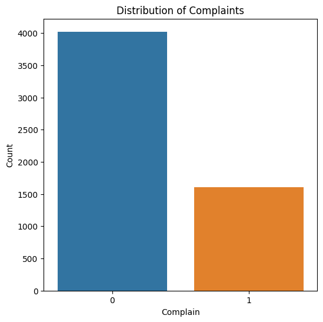

```python
plt.figure(figsize=(6, 6))
sns.countplot(data=df, x='Complain')
plt.title('Distribution of Complaints')
plt.xlabel('Complain')
plt.ylabel('Count')
plt.show()
```

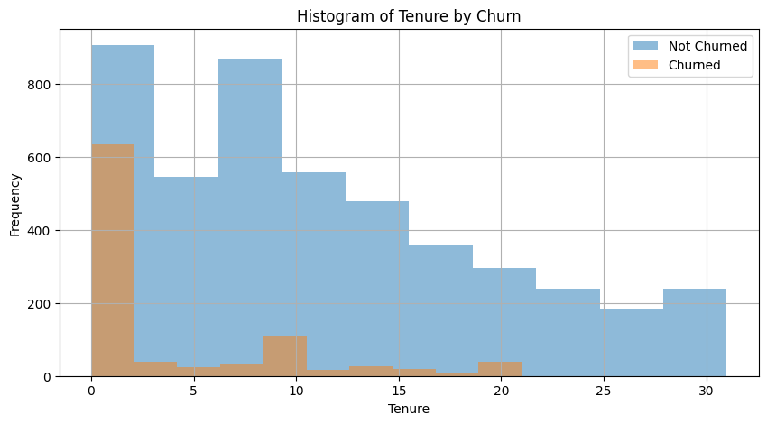

```python
plt.figure(figsize=(10, 5))
df[df['Churn'] == 0]['Tenure'].hist(alpha=0.5, label='Not Churned')
df[df['Churn'] == 1]['Tenure'].hist(alpha=0.5, label='Churned')
plt.title('Histogram of Tenure by Churn')
plt.xlabel('Tenure')
plt.ylabel('Frequency')
plt.legend()
plt.show()
```

From this plot, we observe that most customers who are at risk of leaving the company have a tenure of customers is 0-1 months.

```python
c = df['Churn'] == True
churned_customer_count = c.sum()
total_customer_count = len(df)
print(f"Churned customer count: {churned_customer_count} out of {total_customer_count}")
```

```
Churned customer count: 948 out of 5624
```

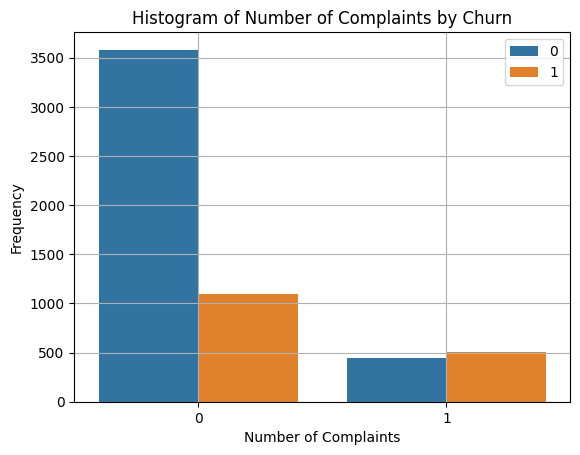

```python
sns.countplot(data=df, x='Churn', hue='Complain')
plt.title('Histogram of Number of Complaints by Churn')
plt.xlabel('Number of Complaints')
plt.ylabel('Frequency')
plt.legend()
plt.grid(True)
plt.show()
```

Churned customer count: 948 out of 5624.

The number of customers who had complaints and are at risk of leaving the company is 508.  
From this, we can get an insight that may be due to the complaints not being resolved, leads them to leave.

```python
churned_complaints = df[(df['Churn'] == 1) & (df['Complain'] == 1)].shape[0]
print("The number of customer risk to leave having complaints: ",churned_complaints)
```

```
The number of customer risk to leave having complaints:  508
```

Piechart for PreferredPaymentMode

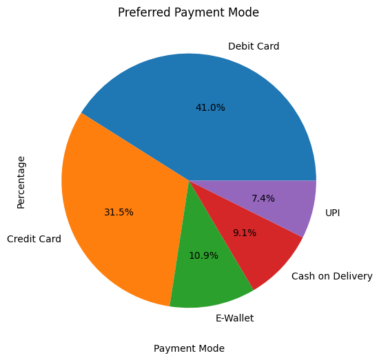

```python
plt.figure(figsize=(10, 6))
df['PreferredPaymentMode'].value_counts().plot(kind='pie', autopct='%1.1f%%')
plt.title('Preferred Payment Mode')
plt.xlabel('Payment Mode')
plt.ylabel('Percentage')
plt.grid(True)
plt.show()
```

Number of hours spent on the app:

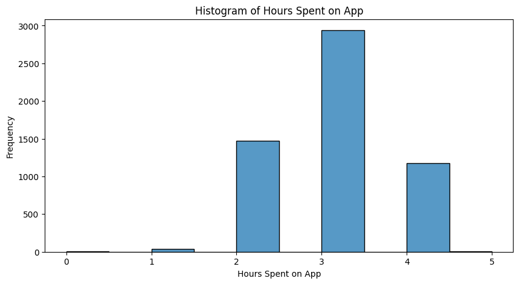

```python
plt.figure(figsize=(10, 5))
sns.histplot(df['HourSpendOnApp'], bins = 10)
plt.title('Histogram of Hours Spent on App')
plt.xlabel('Hours Spent on App')
plt.ylabel('Frequency')
plt.show()
```

Almost 3000 customers spent 3 hours using the application.

Churn vs SatisfactionScore

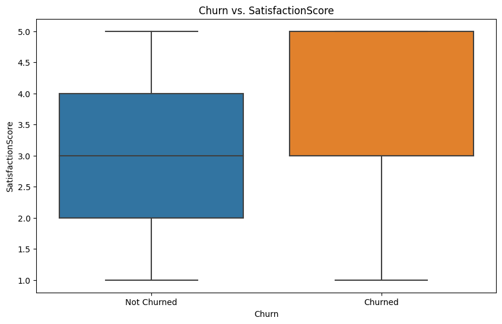

```python
# Plotting Churn vs. SatisfactionScore
plt.figure(figsize=(10, 6))
sns.boxplot(x='Churn', y='SatisfactionScore', data=df)
plt.title('Churn vs. SatisfactionScore')
plt.xlabel('Churn')
plt.ylabel('SatisfactionScore')
plt.xticks([0, 1], ['Not Churned', 'Churned'])
plt.show()
```

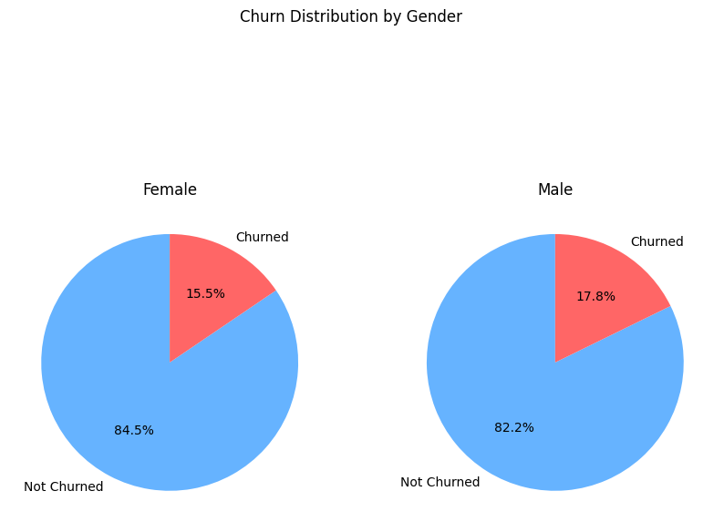

```python
churn_by_gender = df.groupby(['Gender', 'Churn']).size().unstack()

# Plot pie charts
fig, axes = plt.subplots(1, 2, figsize=(10, 8))

# Pie chart for Female
axes[0].pie(churn_by_gender.loc['Female'], labels=['Not Churned', 'Churned'], autopct='%1.1f%%', startangle=90, colors=['#66b3ff', '#ff6666'])
axes[0].set_title('Female')

# Pie chart for Male
axes[1].pie(churn_by_gender.loc['Male'], labels=['Not Churned', 'Churned'], autopct='%1.1f%%', startangle=90, colors=['#66b3ff', '#ff6666'])
axes[1].set_title('Male')

plt.suptitle('Churn Distribution by Gender')
plt.show()
```

There is a small difference between the churn rates of male and female customers, with males having a slightly higher churn rate (17.8%) compared to females (15.5%).

#### Correlation matrix:

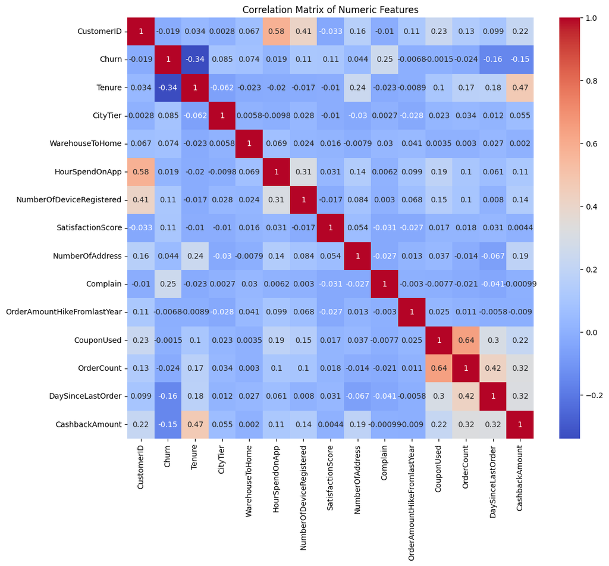

```python
# Exclude non-numeric
numeric_df = df.select_dtypes(include=[np.number])

#correlation matrix
corr_matrix = numeric_df.corr()
plt.figure(figsize=(12, 10))
sns.heatmap(corr_matrix, annot=True, cmap='coolwarm')
plt.title('Correlation Matrix of Numeric Features')
plt.show()
```

#### `MODEL SELECTION`

```python
# Encode categorical variables
categorical_cols = df.select_dtypes(include=['object', 'category']).columns
for col in categorical_cols:
    le = LabelEncoder()
    df[col] = le.fit_transform(df[col].astype(str))

# Split the data into features and target variable
X = df.drop(columns=['Churn'])
y = df['Churn']

# Scale the features
scaler = StandardScaler()
X_scaled = scaler.fit_transform(X)

# Split the data into training and testing sets
X_train, X_test, y_train, y_test = train_test_split(X_scaled, y, test_size=0.2, random_state=42)
```

```python
# Initialize the models
log_reg = LogisticRegression()
rf = RandomForestClassifier()
gb = GradientBoostingClassifier()
xgb = XGBClassifier()

# Train and evaluate the models
models = {'Logistic Regression': log_reg,
          'Random Forest': rf,
          'Gradient Boosting': gb,
          'XGBoost': xgb}

results = {}

for model_name, model in models.items():
    model.fit(X_train, y_train)
    y_pred = model.predict(X_test)
    accuracy = accuracy_score(y_test, y_pred)
    f1 = f1_score(y_test, y_pred)
    roc_auc = roc_auc_score(y_test, y_pred)

    # Cross-validation score
    cv_score = cross_val_score(model, X_scaled, y, cv=5, scoring='accuracy').mean()

    results[model_name] = {'Accuracy': accuracy,
                           'F1 Score': f1,
                           'ROC AUC Score': roc_auc,
                           'Cross-Validation Score': cv_score}

results_df = pd.DataFrame(results).T
results_df
```

|  | Accuracy | F1 Score | ROC AUC Score | Cross-Validation Score |
| --- | --- | --- | --- | --- |
| Logistic Regression | 0.892444 | 0.595318 | 0.731349 | 0.879268 |
| Random Forest | 0.964444 | 0.884393 | 0.918122 | 0.929775 |
| Gradient Boosting | 0.919111 | 0.728358 | 0.821429 | 0.889228 |
| XGBoost | 0.966222 | 0.893855 | 0.934921 | 0.980973 |

#### Conclusion:

Models Random Forest and XGBoost gave the highest accuracy on the test data, which is almost 96%. They gave the highest cross-validation score compared to other models.